# House - price prediction

#### Importing libraries which we need to plot

```python
import pandas as pd
import matplotlib.pyplot as plt
import seaborn as sns
%matplotlib inline
```

#### Read the Data set of house_price prediction which is available in csv

```python
df=pd.read_csv("https://raw.githubusercontent.com/Shreyas3108/house-price-prediction/master/kc_house_data.csv")
```

```python
df.head(5)
```

|  | id | date | price | bedrooms | bathrooms | sqft_living | sqft_lot | floors | waterfront | view | ... | grade | sqft_above | sqft_basement | yr_built | yr_renovated | zipcode | lat | long | sqft_living15 | sqft_lot15 |
| --- | --- | --- | --- | --- | --- | --- | --- | --- | --- | --- | --- | --- | --- | --- | --- | --- | --- | --- | --- | --- | --- |
| 0 | 7129300520 | 20141013T000000 | 221900.0 | 3 | 1.00 | 1180 | 5650 | 1.0 | 0 | 0 | ... | 7 | 1180 | 0 | 1955 | 0 | 98178 | 47.5112 | -122.257 | 1340 | 5650 |
| 1 | 6414100192 | 20141209T000000 | 538000.0 | 3 | 2.25 | 2570 | 7242 | 2.0 | 0 | 0 | ... | 7 | 2170 | 400 | 1951 | 1991 | 98125 | 47.7210 | -122.319 | 1690 | 7639 |
| 2 | 5631500400 | 20150225T000000 | 180000.0 | 2 | 1.00 | 770 | 10000 | 1.0 | 0 | 0 | ... | 6 | 770 | 0 | 1933 | 0 | 98028 | 47.7379 | -122.233 | 2720 | 8062 |
| 3 | 2487200875 | 20141209T000000 | 604000.0 | 4 | 3.00 | 1960 | 5000 | 1.0 | 0 | 0 | ... | 7 | 1050 | 910 | 1965 | 0 | 98136 | 47.5208 | -122.393 | 1360 | 5000 |
| 4 | 1954400510 | 20150218T000000 | 510000.0 | 3 | 2.00 | 1680 | 8080 | 1.0 | 0 | 0 | ... | 8 | 1680 | 0 | 1987 | 0 | 98074 | 47.6168 | -122.045 | 1800 | 7503 |

5 rows × 21 columns

You can also check shape of DataFrame by using .shape

```python
df.shape
```

```
(21613, 21)
```

You can also check size od DataFrame by using .size

```python
df.size
```

```
453873
```

To get the described view of dataframe of dataset we use described function,which gives us described form of all columns,as we can see like count,mean,max,min and many more.Also, use the DataFrame .describe() method to check out summary statistics of numeric columns

```python
df.describe(include='all')
```

|  | id | date | price | bedrooms | bathrooms | sqft_living | sqft_lot | floors | waterfront | view | ... | grade | sqft_above | sqft_basement | yr_built | yr_renovated | zipcode | lat | long | sqft_living15 | sqft_lot15 |
| --- | --- | --- | --- | --- | --- | --- | --- | --- | --- | --- | --- | --- | --- | --- | --- | --- | --- | --- | --- | --- | --- |
| count | 2.161300e+04 | 21613 | 2.161300e+04 | 21613.000000 | 21613.000000 | 21613.000000 | 2.161300e+04 | 21613.000000 | 21613.000000 | 21613.000000 | ... | 21613.000000 | 21613.000000 | 21613.000000 | 21613.000000 | 21613.000000 | 21613.000000 | 21613.000000 | 21613.000000 | 21613.000000 | 21613.000000 |
| unique | NaN | 372 | NaN | NaN | NaN | NaN | NaN | NaN | NaN | NaN | ... | NaN | NaN | NaN | NaN | NaN | NaN | NaN | NaN | NaN | NaN |
| top | NaN | 20140623T000000 | NaN | NaN | NaN | NaN | NaN | NaN | NaN | NaN | ... | NaN | NaN | NaN | NaN | NaN | NaN | NaN | NaN | NaN | NaN |
| freq | NaN | 142 | NaN | NaN | NaN | NaN | NaN | NaN | NaN | NaN | ... | NaN | NaN | NaN | NaN | NaN | NaN | NaN | NaN | NaN | NaN |
| mean | 4.580302e+09 | NaN | 5.400881e+05 | 3.370842 | 2.114757 | 2079.899736 | 1.510697e+04 | 1.494309 | 0.007542 | 0.234303 | ... | 7.656873 | 1788.390691 | 291.509045 | 1971.005136 | 84.402258 | 98077.939805 | 47.560053 | -122.213896 | 1986.552492 | 12768.455652 |
| std | 2.876566e+09 | NaN | 3.671272e+05 | 0.930062 | 0.770163 | 918.440897 | 4.142051e+04 | 0.539989 | 0.086517 | 0.766318 | ... | 1.175459 | 828.090978 | 442.575043 | 29.373411 | 401.679240 | 53.505026 | 0.138564 | 0.140828 | 685.391304 | 27304.179631 |
| min | 1.000102e+06 | NaN | 7.500000e+04 | 0.000000 | 0.000000 | 290.000000 | 5.200000e+02 | 1.000000 | 0.000000 | 0.000000 | ... | 1.000000 | 290.000000 | 0.000000 | 1900.000000 | 0.000000 | 98001.000000 | 47.155900 | -122.519000 | 399.000000 | 651.000000 |
| 25% | 2.123049e+09 | NaN | 3.219500e+05 | 3.000000 | 1.750000 | 1427.000000 | 5.040000e+03 | 1.000000 | 0.000000 | 0.000000 | ... | 7.000000 | 1190.000000 | 0.000000 | 1951.000000 | 0.000000 | 98033.000000 | 47.471000 | -122.328000 | 1490.000000 | 5100.000000 |
| 50% | 3.904930e+09 | NaN | 4.500000e+05 | 3.000000 | 2.250000 | 1910.000000 | 7.618000e+03 | 1.500000 | 0.000000 | 0.000000 | ... | 7.000000 | 1560.000000 | 0.000000 | 1975.000000 | 0.000000 | 98065.000000 | 47.571800 | -122.230000 | 1840.000000 | 7620.000000 |
| 75% | 7.308900e+09 | NaN | 6.450000e+05 | 4.000000 | 2.500000 | 2550.000000 | 1.068800e+04 | 2.000000 | 0.000000 | 0.000000 | ... | 8.000000 | 2210.000000 | 560.000000 | 1997.000000 | 0.000000 | 98118.000000 | 47.678000 | -122.125000 | 2360.000000 | 10083.000000 |
| max | 9.900000e+09 | NaN | 7.700000e+06 | 33.000000 | 8.000000 | 13540.000000 | 1.651359e+06 | 3.500000 | 1.000000 | 4.000000 | ... | 13.000000 | 9410.000000 | 4820.000000 | 2015.000000 | 2015.000000 | 98199.000000 | 47.777600 | -121.315000 | 6210.000000 | 871200.000000 |

11 rows × 21 columns

To see is there any null value present in dataset we use isnull() with sum up operation . As we see there is no null value present in dataset,If null vlaue present inthe dataset then we have to remove that null values

```python
df.isnull().sum()
```

```
id               0
date             0
price            0
bedrooms         0
bathrooms        0
sqft_living      0
sqft_lot         0
floors           0
waterfront       0
view             0
condition        0
grade            0
sqft_above       0
sqft_basement    0
yr_built         0
yr_renovated     0
zipcode          0
lat              0
long             0
sqft_living15    0
sqft_lot15       0
dtype: int64
```

# Univariate Analysis

Uni means one.Univariate means one variable analysis.Univariate analysis explores each variable in a data set. Variables could be either categorical or numerical.There are different statistical and visualization techniques of investigation for each type of variable.The key pointers to the univariate analysis is to find out outliers present in data.

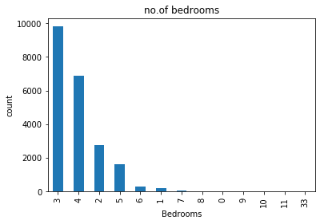

```python
df['bedrooms'].value_counts().plot(kind='bar')
plt.xlabel("Bedrooms")
plt.ylabel("count")
plt.title("no.of bedrooms")
plt.show()
```

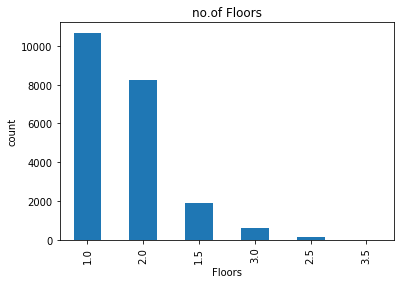

```python
df['floors'].value_counts().plot(kind='bar')
plt.xlabel("Floors")
plt.ylabel("count")
plt.title("no.of Floors")
plt.show()
```

## Bivariate analysis

Bivariate analysis is the simultaneous analysis of two variables (attributes). It explores the concept of relationship between two variables, whether there exists an association and the strength of this association, or whether there are differences between two variables and the significance of these differences.

### What is/are the main feature(s) of interest in your dataset?

The price of the house is what ulimately matters the most, all the other inputs combination is to produce a certain kind of patterns which is attributed to price of house.

```python
df.corr()
```

|  | id | date | price | bedrooms | bathrooms | sqft_living | sqft_lot | floors | waterfront | view | ... | grade | sqft_above | sqft_basement | yr_built | yr_renovated | zipcode | lat | long | sqft_living15 | sqft_lot15 |
| --- | --- | --- | --- | --- | --- | --- | --- | --- | --- | --- | --- | --- | --- | --- | --- | --- | --- | --- | --- | --- | --- |
| id | 1.000000 | NaN | -0.016762 | 0.001286 | 0.005160 | -0.012258 | -0.132109 | 0.018525 | -0.002721 | 0.011592 | ... | 0.008130 | -0.010842 | -0.005151 | 0.021380 | -0.016907 | -0.008224 | -0.001891 | 0.020799 | -0.002901 | -0.138798 |
| date | NaN | NaN | NaN | NaN | NaN | NaN | NaN | NaN | NaN | NaN | ... | NaN | NaN | NaN | NaN | NaN | NaN | NaN | NaN | NaN | NaN |
| price | -0.016762 | NaN | 1.000000 | 0.308350 | 0.525138 | 0.702035 | 0.089661 | 0.256794 | 0.266369 | 0.397293 | ... | 0.667434 | 0.605567 | 0.323816 | 0.054012 | 0.126434 | -0.053203 | 0.307003 | 0.021626 | 0.585379 | 0.082447 |
| bedrooms | 0.001286 | NaN | 0.308350 | 1.000000 | 0.515884 | 0.576671 | 0.031703 | 0.175429 | -0.006582 | 0.079532 | ... | 0.356967 | 0.477600 | 0.303093 | 0.154178 | 0.018841 | -0.152668 | -0.008931 | 0.129473 | 0.391638 | 0.029244 |
| bathrooms | 0.005160 | NaN | 0.525138 | 0.515884 | 1.000000 | 0.754665 | 0.087740 | 0.500653 | 0.063744 | 0.187737 | ... | 0.664983 | 0.685342 | 0.283770 | 0.506019 | 0.050739 | -0.203866 | 0.024573 | 0.223042 | 0.568634 | 0.087175 |
| sqft_living | -0.012258 | NaN | 0.702035 | 0.576671 | 0.754665 | 1.000000 | 0.172826 | 0.353949 | 0.103818 | 0.284611 | ... | 0.762704 | 0.876597 | 0.435043 | 0.318049 | 0.055363 | -0.199430 | 0.052529 | 0.240223 | 0.756420 | 0.183286 |
| sqft_lot | -0.132109 | NaN | 0.089661 | 0.031703 | 0.087740 | 0.172826 | 1.000000 | -0.005201 | 0.021604 | 0.074710 | ... | 0.113621 | 0.183512 | 0.015286 | 0.053080 | 0.007644 | -0.129574 | -0.085683 | 0.229521 | 0.144608 | 0.718557 |
| floors | 0.018525 | NaN | 0.256794 | 0.175429 | 0.500653 | 0.353949 | -0.005201 | 1.000000 | 0.023698 | 0.029444 | ... | 0.458183 | 0.523885 | -0.245705 | 0.489319 | 0.006338 | -0.059121 | 0.049614 | 0.125419 | 0.279885 | -0.011269 |
| waterfront | -0.002721 | NaN | 0.266369 | -0.006582 | 0.063744 | 0.103818 | 0.021604 | 0.023698 | 1.000000 | 0.401857 | ... | 0.082775 | 0.072075 | 0.080588 | -0.026161 | 0.092885 | 0.030285 | -0.014274 | -0.041910 | 0.086463 | 0.030703 |
| view | 0.011592 | NaN | 0.397293 | 0.079532 | 0.187737 | 0.284611 | 0.074710 | 0.029444 | 0.401857 | 1.000000 | ... | 0.251321 | 0.167649 | 0.276947 | -0.053440 | 0.103917 | 0.084827 | 0.006157 | -0.078400 | 0.280439 | 0.072575 |
| condition | -0.023783 | NaN | 0.036362 | 0.028472 | -0.124982 | -0.058753 | -0.008958 | -0.263768 | 0.016653 | 0.045990 | ... | -0.144674 | -0.158214 | 0.174105 | -0.361417 | -0.060618 | 0.003026 | -0.014941 | -0.106500 | -0.092824 | -0.003406 |
| grade | 0.008130 | NaN | 0.667434 | 0.356967 | 0.664983 | 0.762704 | 0.113621 | 0.458183 | 0.082775 | 0.251321 | ... | 1.000000 | 0.755923 | 0.168392 | 0.446963 | 0.014414 | -0.184862 | 0.114084 | 0.198372 | 0.713202 | 0.119248 |
| sqft_above | -0.010842 | NaN | 0.605567 | 0.477600 | 0.685342 | 0.876597 | 0.183512 | 0.523885 | 0.072075 | 0.167649 | ... | 0.755923 | 1.000000 | -0.051943 | 0.423898 | 0.023285 | -0.261190 | -0.000816 | 0.343803 | 0.731870 | 0.194050 |
| sqft_basement | -0.005151 | NaN | 0.323816 | 0.303093 | 0.283770 | 0.435043 | 0.015286 | -0.245705 | 0.080588 | 0.276947 | ... | 0.168392 | -0.051943 | 1.000000 | -0.133124 | 0.071323 | 0.074845 | 0.110538 | -0.144765 | 0.200355 | 0.017276 |
| yr_built | 0.021380 | NaN | 0.054012 | 0.154178 | 0.506019 | 0.318049 | 0.053080 | 0.489319 | -0.026161 | -0.053440 | ... | 0.446963 | 0.423898 | -0.133124 | 1.000000 | -0.224874 | -0.346869 | -0.148122 | 0.409356 | 0.326229 | 0.070958 |
| yr_renovated | -0.016907 | NaN | 0.126434 | 0.018841 | 0.050739 | 0.055363 | 0.007644 | 0.006338 | 0.092885 | 0.103917 | ... | 0.014414 | 0.023285 | 0.071323 | -0.224874 | 1.000000 | 0.064357 | 0.029398 | -0.068372 | -0.002673 | 0.007854 |
| zipcode | -0.008224 | NaN | -0.053203 | -0.152668 | -0.203866 | -0.199430 | -0.129574 | -0.059121 | 0.030285 | 0.084827 | ... | -0.184862 | -0.261190 | 0.074845 | -0.346869 | 0.064357 | 1.000000 | 0.267048 | -0.564072 | -0.279033 | -0.147221 |
| lat | -0.001891 | NaN | 0.307003 | -0.008931 | 0.024573 | 0.052529 | -0.085683 | 0.049614 | -0.014274 | 0.006157 | ... | 0.114084 | -0.000816 | 0.110538 | -0.148122 | 0.029398 | 0.267048 | 1.000000 | -0.135512 | 0.048858 | -0.086419 |
| long | 0.020799 | NaN | 0.021626 | 0.129473 | 0.223042 | 0.240223 | 0.229521 | 0.125419 | -0.041910 | -0.078400 | ... | 0.198372 | 0.343803 | -0.144765 | 0.409356 | -0.068372 | -0.564072 | -0.135512 | 1.000000 | 0.334605 | 0.254451 |
| sqft_living15 | -0.002901 | NaN | 0.585379 | 0.391638 | 0.568634 | 0.756420 | 0.144608 | 0.279885 | 0.086463 | 0.280439 | ... | 0.713202 | 0.731870 | 0.200355 | 0.326229 | -0.002673 | -0.279033 | 0.048858 | 0.334605 | 1.000000 | 0.183192 |
| sqft_lot15 | -0.138798 | NaN | 0.082447 | 0.029244 | 0.087175 | 0.183286 | 0.718557 | -0.011269 | 0.030703 | 0.072575 | ... | 0.119248 | 0.194050 | 0.017276 | 0.070958 | 0.007854 | -0.147221 | -0.086419 | 0.254451 | 0.183192 | 1.000000 |

21 rows × 21 columns

### HeatMap

A heat map (or heatmap) is a graphical representation of data where the individual values contained in a matrix are represented as colors.This heatmap showing the correlation between all the variables present in the dataframe.

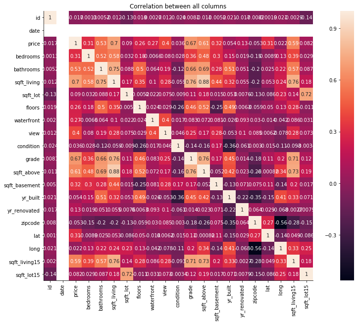

```python
plt.figure(figsize=(20,10))
sns.heatmap(df.corr(),annot=True,square=True)
sns.despine()
plt.title("Correlation between all columns")
plt.show()
```

### bedroom v/s price

1. AS from the above we can see the correlation b/w the bedroom and price which is 0.31.
2. five number of bedrooms have high price b/w 5000000 to 6000000.
3. three or four no. of bedrooms have upto 4000000.

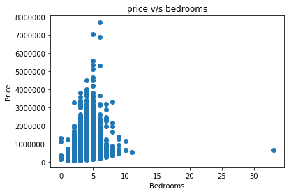

```python
plt.scatter(df.bedrooms,df.price)
plt.xlabel("Bedrooms")
plt.ylabel("Price")
plt.title("price v/s bedrooms")
plt.show()
```

### Sqft_living v/s Price

1. As from heatmap we can see that there is strong correlation b/w these two.
2. As square feet of living increases ,the price also increses.

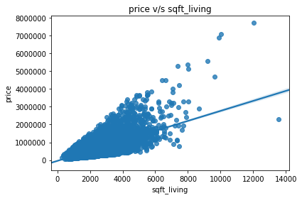

```python
sns.regplot(x='sqft_living',y='price',data=df)

plt.title("price v/s sqft_living")
plt.show()
```

### Floors v/s Price

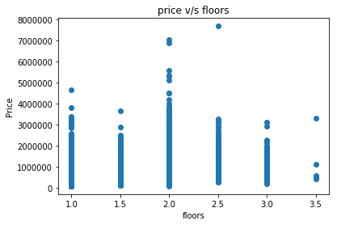

```python
plt.scatter(df.floors,df.price,data=df)
plt.xlabel("floors")
plt.ylabel("Price")
plt.title("price v/s floors")
plt.show()
```

### Waterfront v/s Price

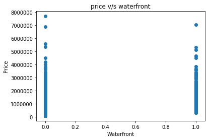

```python
plt.scatter(df.waterfront,df.price,data=df)
plt.xlabel("Waterfront")
plt.ylabel("Price")
plt.title("price v/s waterfront")
plt.show()
```

### Bathrooms v/s Price

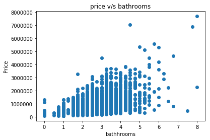

```python
plt.scatter(df.bathrooms,df.price,data=df)
plt.xlabel("bathhrooms")
plt.ylabel("Price")
plt.title("price v/s bathrooms")
plt.show()
```

### Sqft_basement v/s Price

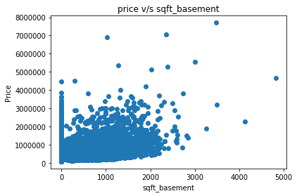

```python
plt.scatter(df.sqft_basement,df.price,data=df)
plt.xlabel("sqft_basement")
plt.ylabel("Price")
plt.title("price v/s sqft_basement")
plt.show()
```

### Zipcode v/s price

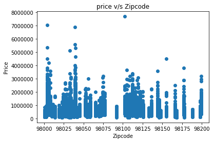

```python
plt.scatter(df.zipcode,df.price,data=df)
plt.xlabel("Zipcode")
plt.ylabel("Price")
plt.title("price v/s Zipcode")
plt.show()
```

### LinearRegression

The term ”linearity” in algebra refers to a linear relationship between two or more variables. If we draw this relationship in a two dimensional space (between two variables, in this case), we get a straight line.

```python
from sklearn.linear_model import LinearRegression
```

```python
lreg=LinearRegression()
```

```python
lreg
```

```
LinearRegression(copy_X=True, fit_intercept=True, n_jobs=1, normalize=False)
```

```python
labels=df['price']
conv_dates=[1 if values==2014 else 0 for values in df.date]
df['date']=conv_dates
train=df.drop(['id','price'],axis=1)
```

```python
from sklearn.cross_validation import train_test_split
```

```python
x_train,x_test,y_train,y_test=train_test_split(train,labels,test_size=0.30,random_state=2)
```

At this we train our model.

```python
lreg.fit(x_train,y_train)
```

```
LinearRegression(copy_X=True, fit_intercept=True, n_jobs=1, normalize=False)
```

At this point we test are model

```python
lreg.score(x_test,y_test)
```

```
0.7069046794131526
```